# Trabajo de regresión logística

Pablo Opazo - Mario Guajardo

8/17/2021

## Carga, limpieza y formato de los datos

### A.- Cargue los datos en R y revise los formatos de cada variable, recuerde codificar las variables como numé ricas o factores según corresponda.

```r
rh_data <- read.csv("datos/rrhh.csv", encoding = "UTF-8")

rh_data <- rename(rh_data, Ratio_Pago = Ratio.Pago)
rh_data <- rename(rh_data, Estado_Civil = Estado.Civil)
rh_data <- rename(rh_data, Dias_Trabajados = Dias.trabajados)
rh_data <- rename(rh_data, Desempenio = Desempeño)


rh_data <- rh_data %>% mutate(Sexo = as.factor(Sexo),
                              Estado_Civil = as.factor(Estado_Civil),
                              Departamento = as.factor(Departamento),
                              Posicion = as.factor(Posicion),
                              Desempenio = as.factor(Desempenio))
```

## Análisis descriptivo y exploratorio de datos

### Realice un análisis descriptivo de sus datos. Determinar si existen observaciones faltantes, en el caso de existir tome la decisión de omitirlas del estudio u omitir la variable. Evalúe si existen posibles incongruencias en la fuente de datos (ej: edades negativas). Y finalmente análice la presencia de valores atípicos en las variables.

```r
skimr::skim(rh_data)
```

Data summary

| Name | rh_data |
| --- | --- |
| Number of rows | 310 |
| Number of columns | 11 |
| _______________________ |  |
| Column type frequency: |  |
| factor | 5 |
| numeric | 6 |
| ________________________ |  |
| Group variables | None |

**Variable type: factor**

| skim_variable | n_missing | complete_rate | ordered | n_unique | top_counts |
| --- | --- | --- | --- | --- | --- |
| Sexo | 0 | 1 | FALSE | 2 | Fem: 177, Mal: 133 |
| Estado_Civil | 0 | 1 | FALSE | 5 | 4: 137, 2: 123, 1: 30, 3: 12 |
| Departamento | 0 | 1 | FALSE | 6 | Pro: 208, IT/: 50, Sal: 31, Adm: 10 |
| Posicion | 0 | 1 | FALSE | 28 | Pro: 136, Pro: 57, Are: 27, Pro: 14 |
| Desempenio | 0 | 1 | FALSE | 7 | Ful: 181, N/A: 37, 90-: 31, Exc: 28 |

**Variable type: numeric**

| skim_variable | n_missing | complete_rate | mean | sd | p0 | p25 | p50 | p75 | p100 | hist |
| --- | --- | --- | --- | --- | --- | --- | --- | --- | --- | --- |
| Estado | 0 | 1 | 0.41 | 0.49 | 0.0 | 0.00 | 0.00 | 1.00 | 1.00 | ▇▁▁▁▆ |
| Edad | 0 | 1 | 38.87 | 8.92 | 25.0 | 32.00 | 37.00 | 44.00 | 67.00 | ▇▇▅▂▁ |
| Ratio_Pago | 0 | 1 | 31.28 | 15.38 | 14.0 | 20.00 | 24.00 | 45.31 | 80.00 | ▇▂▂▂▁ |
| Salario | 0 | 1 | 4606.53 | 1677.35 | 3004.6 | 3707.03 | 4190.67 | 4804.73 | 16666.67 | ▇▁▁▁▁ |
| Dias_Trabajados | 0 | 1 | 1296.08 | 769.49 | 2.0 | 766.25 | 1238.00 | 1732.75 | 4339.00 | ▅▇▃▁▁ |
| Ausencias | 0 | 1 | 10.26 | 5.84 | 1.0 | 5.00 | 10.00 | 15.00 | 20.00 | ▇▆▅▇▆ |

```r
str(rh_data)
```

```
## 'data.frame':    310 obs. of  11 variables:
##  $ Estado         : int  0 0 0 0 0 1 0 1 0 0 ...
##  $ Edad           : num  30 34 31 32 30 30 33 33 31 39 ...
##  $ Ratio_Pago     : num  28.5 23 29 21.5 16.6 ...
##  $ Salario        : num  4167 6962 4330 4333 3388 ...
##  $ Dias_Trabajados: int  3317 1420 1154 58 940 730 691 1636 1014 3247 ...
##  $ Ausencias      : int  1 17 3 15 2 15 19 19 4 16 ...
##  $ Sexo           : Factor w/ 2 levels "Female","Male": 1 2 2 1 1 1 2 2 1 1 ...
##  $ Estado_Civil   : Factor w/ 5 levels "1","2","3","4",..: 2 1 4 2 4 2 2 2 2 2 ...
##  $ Departamento   : Factor w/ 6 levels "Admin Offices",..: 1 1 1 1 1 1 1 1 1 1 ...
##  $ Posicion       : Factor w/ 28 levels "Accountant I",..: 1 1 1 2 2 2 23 23 26 26 ...
##  $ Desempenio     : Factor w/ 7 levels "90-day meets",..: 4 4 4 5 5 4 4 4 1 4 ...
```

**Respuesta**:

```
Se comprueba que los datos están Ok, no presentan datos nulos por lo que se podrá trabajar directamente con ellos
```

```r
summary(rh_data)
```

```
##      Estado            Edad         Ratio_Pago       Salario
##  Min.   :0.0000   Min.   :25.00   Min.   :14.00   Min.   : 3005
##  1st Qu.:0.0000   1st Qu.:32.00   1st Qu.:20.00   1st Qu.: 3707
##  Median :0.0000   Median :37.00   Median :24.00   Median : 4191
##  Mean   :0.4097   Mean   :38.87   Mean   :31.28   Mean   : 4607
##  3rd Qu.:1.0000   3rd Qu.:44.00   3rd Qu.:45.31   3rd Qu.: 4805
##  Max.   :1.0000   Max.   :67.00   Max.   :80.00   Max.   :16667
##
##  Dias_Trabajados    Ausencias         Sexo     Estado_Civil
##  Min.   :   2.0   Min.   : 1.00   Female:177   1: 30
##  1st Qu.: 766.2   1st Qu.: 5.00   Male  :133   2:123
##  Median :1238.0   Median :10.00                3: 12
##  Mean   :1296.1   Mean   :10.26                4:137
##  3rd Qu.:1732.8   3rd Qu.:15.00                5:  8
##  Max.   :4339.0   Max.   :20.00
##
##                Departamento                     Posicion
##  Admin Offices       : 10   Production Technician I :136
##  Executive Office    :  1   Production Technician II: 57
##  IT/IS               : 50   Area Sales Manager      : 27
##  Production          :208   Production Manager      : 14
##  Sales               : 31   Database Administrator  : 13
##  Software Engineering: 10   Network Engineer        :  9
##                             (Other)                 : 54
##                     Desempenio
##  90-day meets            : 31
##  Exceeds                 : 28
##  Exceptional             :  9
##  Fully Meets             :181
##  N/A- too early to review: 37
##  Needs Improvement       : 15
##  PIP                     :  9
```

**Respuesta**:

```
Revisión de medianas, medias, valores mínimos y máximos de variables numéricas.
Revisión de frecuencias en las variables categóricas.
* La variable Estado corresponde a los valores esperados 0 y 1
* La variables númericas son coherentes, no se observan valores mínimos y máximos imposibles
* Revisando la frecuencias de las variables categóricas no se observan categorías ingresadas repetidas ni mal escritas.
```

### Detección de Outliers para variables numéricas continuas

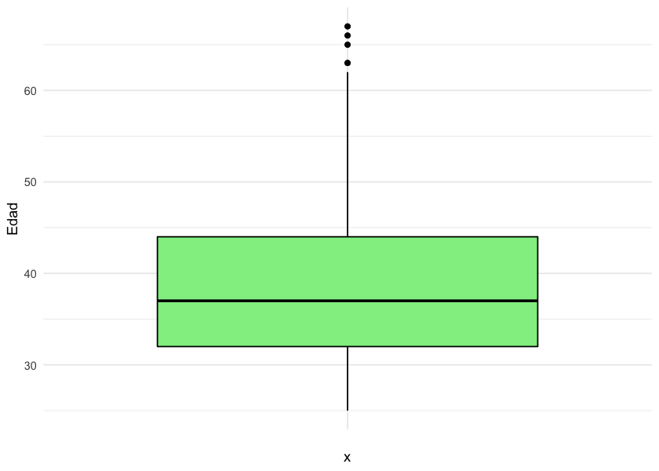

```r
#Edad
ggplot(data= rh_data, aes(x= "",y= Edad)) + geom_boxplot(color="black",fill= "lightgreen") +
theme_minimal()
```

```r
boxplot.stats(rh_data$Edad)$out
```

```
## [1] 63 66 67 63 65 67 66 65 63
```

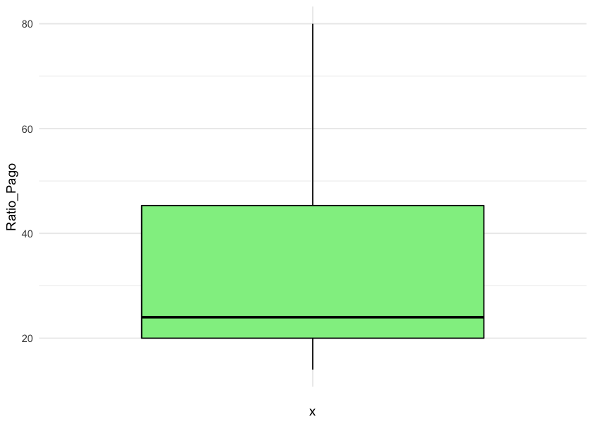

```r
#Ratio de Pago
ggplot(data= rh_data, aes(x= "", y=Ratio_Pago))+geom_boxplot(color="black",fill= "lightgreen") +
theme_minimal()
```

```r
boxplot.stats(rh_data$Ratio_Pago)$out
```

```
## numeric(0)
```

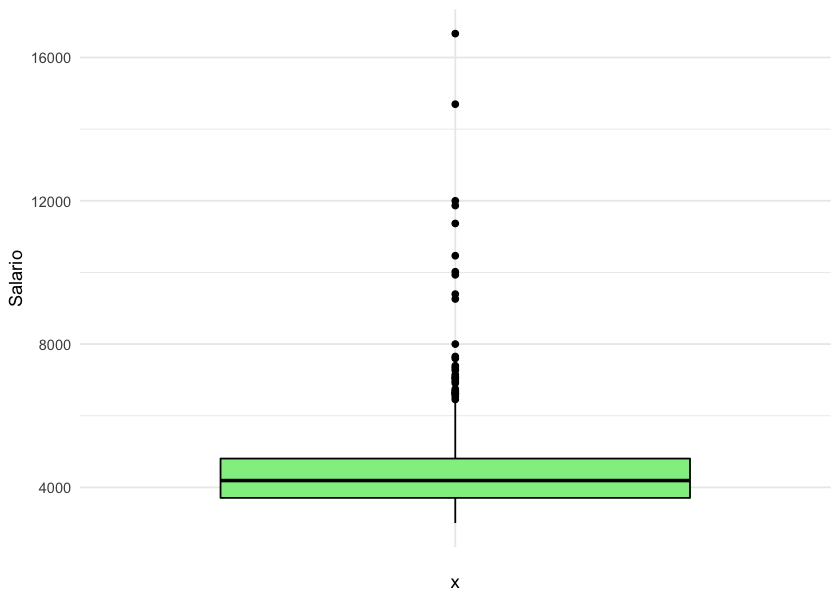

```r
#Salario
ggplot(data= rh_data, aes(x= "",y= Salario)) + geom_boxplot(color="black",fill= "lightgreen") +
theme_minimal()
```

```r
boxplot.stats(rh_data$Salario)$out
```

```
##  [1]  6962.467  7333.333  6907.533  7091.133  6668.733  7395.267 11366.667
##  [8]  6746.600  9259.200  6618.667 11866.667  6623.400  7653.333  6601.333
## [15]  6533.267 12000.000  7046.667 16666.667  7045.867 10466.667  7265.800
## [22]  8000.000 10019.333  9394.667  9933.267  6694.400  7599.933  7148.400
## [29] 14696.667
```

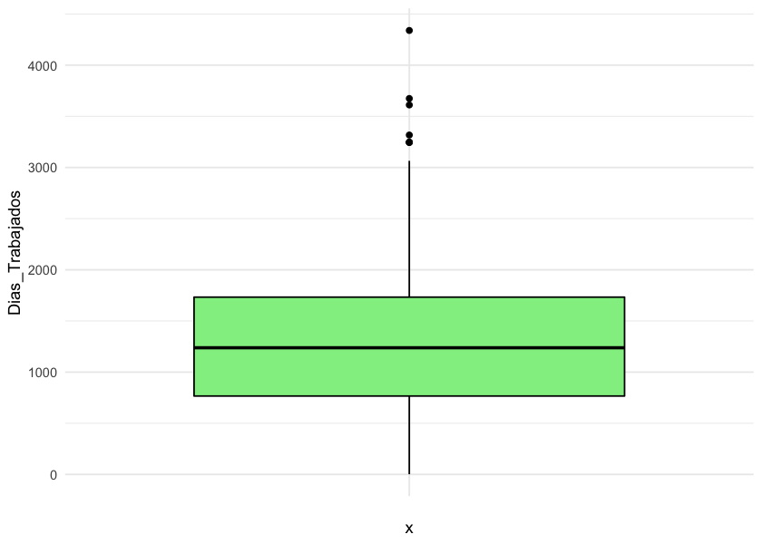

```r
#Dias Trabajados
ggplot(data= rh_data, aes(x= "",y= Dias_Trabajados)) + geom_boxplot(color="black",fill= "lightgreen") +
theme_minimal()
```

```r
boxplot.stats(rh_data$Dias_Trabajados)$out
```

```
## [1] 3317 3247 3247 3244 3611 3674 4339
```

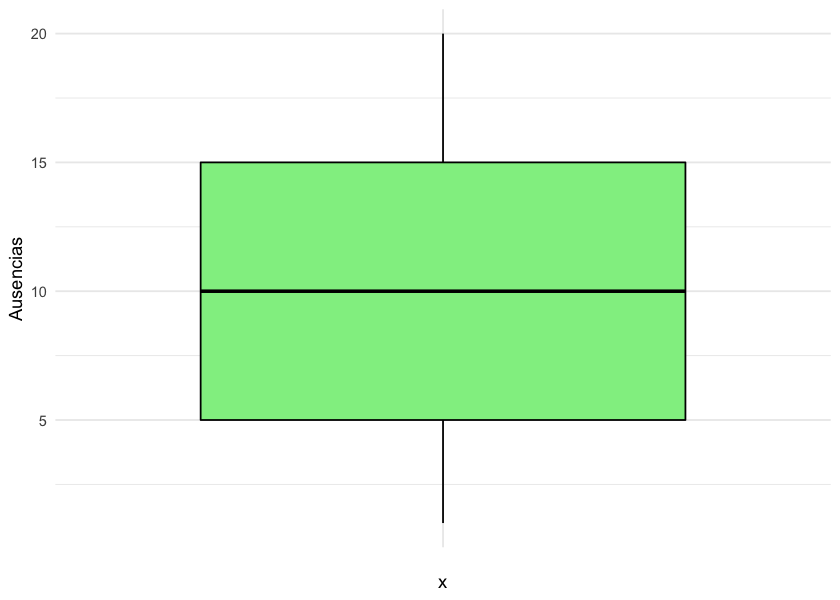

```r
#Ausencias
ggplot(data= rh_data, aes(x= "",y= Ausencias)) + geom_boxplot(color="black",fill= "lightgreen") +
theme_minimal()
```

```r
boxplot.stats(rh_data$Ausencias)$out
```

```
## integer(0)
```

**Respuesta:**

```
Si bien las variables de "Dias Trabajados", "Salario" y "Edad", poseen datos outlier estos son valores completamente coherentes con el tipo de variable, por lo que no se hace ningún cambio a estos outliers encontrados.
```

### C) Realice análisis de cómo se relacionan las variables continuas con la variable de interés. Acompañe con gráficos y estadísticas. ¿Qué variables pudieran resultar significativas a la hora de modelar la probabilidad de que el trabajador sea desvinculado a la empresa?

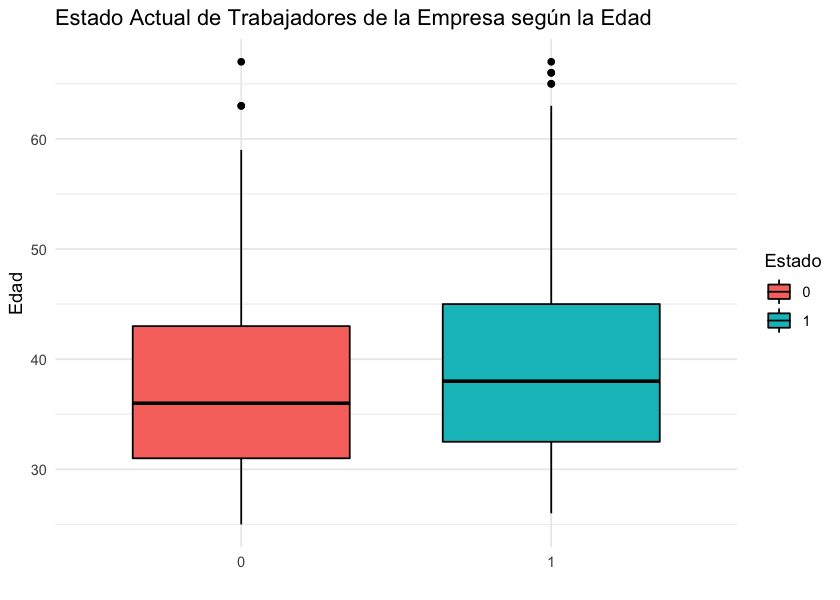

```r
ggpubr::ggboxplot(rh_data, y ="Edad", x="Estado", fill = "Estado")+
  xlab("")+ ylab("Edad")+
  ggtitle("Estado Actual de Trabajadores de la Empresa según la Edad")+ theme_minimal()
```

**Respuesta:**

```
Se puede apreciar que cuando el valor correspondiente a la edad aumenta, puede encontrarse una mayor probabildad de ser desvinculado.
```

```r
anova(aov(Edad~Estado, data=rh_data))
```

```
## Analysis of Variance Table
##
## Response: Edad
##            Df Sum Sq Mean Sq F value  Pr(>F)
## Estado      1    272 271.984  3.4435 0.06446 .
## Residuals 308  24328  78.986
## ---
## Signif. codes:  0 '***' 0.001 '**' 0.01 '*' 0.05 '.' 0.1 ' ' 1
```

**Respuesta:**

```
  La diferencia entre los grupos no seria muy significativa
```

#### Variable de interés Estado y Ratio_Pago

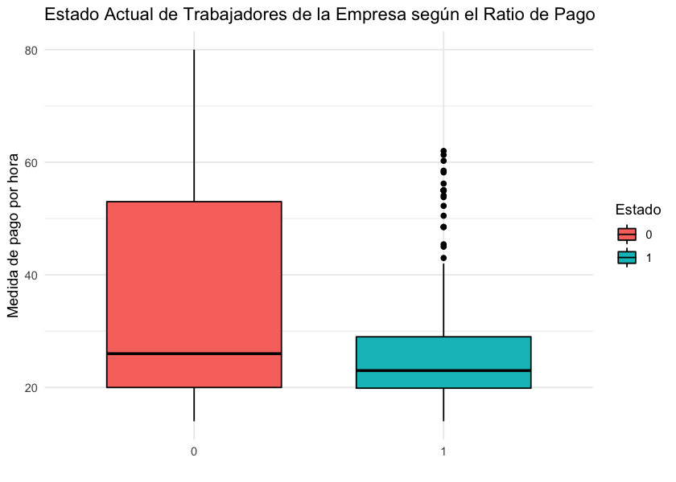

```r
ggpubr::ggboxplot(rh_data, y ="Ratio_Pago", x="Estado", fill = "Estado")+
  xlab("")+ ylab("Medida de pago por hora")+
  ggtitle("Estado Actual de Trabajadores de la Empresa según el Ratio de Pago")+ theme_minimal()
```

**Respuesta**

```
Pareciera que a mayor Ratio de Pago, mas probable es que el trabajador se encuentre   vinculado (0) a la empresa.
```

```r
anova(aov(Ratio_Pago~Estado, data=rh_data))
```

```
## Analysis of Variance Table
##
## Response: Ratio_Pago
##            Df Sum Sq Mean Sq F value    Pr(>F)
## Estado      1   2907 2907.12  12.751 0.0004126 ***
## Residuals 308  70219  227.99
## ---
## Signif. codes:  0 '***' 0.001 '**' 0.01 '*' 0.05 '.' 0.1 ' ' 1
```

**Respuesta:**

```
La diferencia entre los grupos seria muy significativa
```

##### Variable de interés Estado y Salario

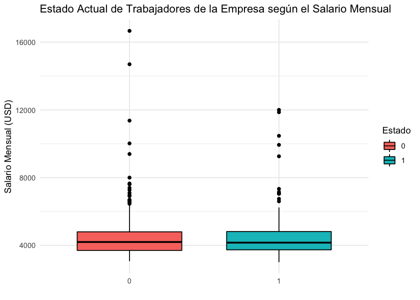

```r
ggpubr::ggboxplot(rh_data, y ="Salario", x="Estado", fill = "Estado")+
  xlab("")+ ylab("Salario Mensual (USD)")+
  ggtitle("Estado Actual de Trabajadores de la Empresa según el Salario Mensual")+ theme_minimal()
```

**Respuesta:**

```
No pareciera que exista mucha diferencia entre los vinculados y desvinculados según el Salario
```

```r
anova(aov(Salario~Estado, data=rh_data))
```

```
## Analysis of Variance Table
##
## Response: Salario
##            Df    Sum Sq Mean Sq F value Pr(>F)
## Estado      1     61134   61134  0.0217 0.8831
## Residuals 308 869311482 2822440
```

**Respuesta:**

```
La diferencia entre los grupos No seria significativa
```

##### Variable de interés Estado y Días Trabajados

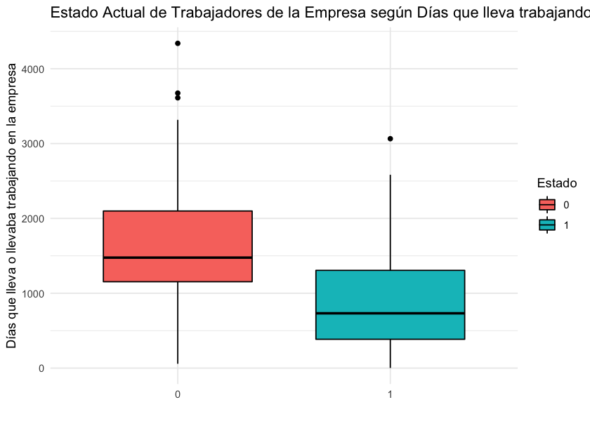

```r
ggpubr::ggboxplot(rh_data, y ="Dias_Trabajados", x="Estado", fill = "Estado")+
  xlab("")+ ylab("Días que lleva o llevaba trabajando en la empresa")+
  ggtitle("Estado Actual de Trabajadores de la Empresa según Días que lleva trabajando")+
  theme_minimal()
```

**Respuesta:**

```
Pareciera que a mayor cantidad de días trabajados que lleva un empleado, mas probable es que el trabajador se encuentre vinculado(0) a la empresa.
```

```r
anova(aov(Dias_Trabajados~Estado, data=rh_data))
```

```
## Analysis of Variance Table
##
## Response: Dias_Trabajados
##            Df    Sum Sq  Mean Sq F value    Pr(>F)
## Estado      1  44824671 44824671  99.942 < 2.2e-16 ***
## Residuals 308 138139478   448505
## ---
## Signif. codes:  0 '***' 0.001 '**' 0.01 '*' 0.05 '.' 0.1 ' ' 1
```

**Respuesta:**

```
La diferencia entre los grupos seria muy significativa
```

##### Variable de interés Estado y Ausencias

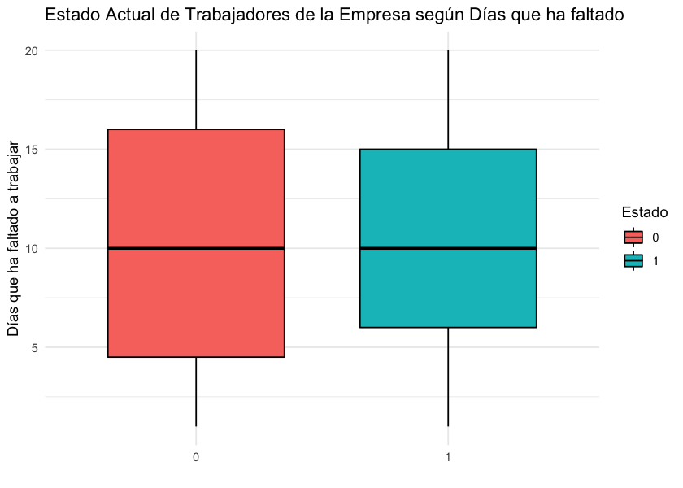

```r
ggpubr::ggboxplot(rh_data, y ="Ausencias", x="Estado", fill = "Estado")+
  xlab("")+ ylab("Días que ha faltado a trabajar")+
  ggtitle("Estado Actual de Trabajadores de la Empresa según Días que ha faltado")+
  theme_minimal()
```

**Respuesta:**

```
No pareciera que exista mucha diferencia entre los vinculados y desvinculados según la cantidad de días que han faltado al Trabajo.
```

```r
anova(aov(Ausencias~Estado, data=rh_data))
```

```
## Analysis of Variance Table
##
## Response: Ausencias
##            Df  Sum Sq Mean Sq F value Pr(>F)
## Estado      1     0.4   0.390  0.0114 0.9151
## Residuals 308 10549.9  34.253
```

**Respuesta:** La diferencia entre los grupos No seria muy significativa

### D) Como se relacionan las variables categóricas con la variable de interés

#### Se Realiza un test χ2 de dependencia, además de mostrar distribución de las frecuencias con tablas de contingencia.

#### Variable de interés Estado y Sexo

```r
prop.table(table(rh_data$Estado, rh_data$Sexo), 2)
```

```
##
##        Female      Male
##   0 0.5706215 0.6165414
##   1 0.4293785 0.3834586
```

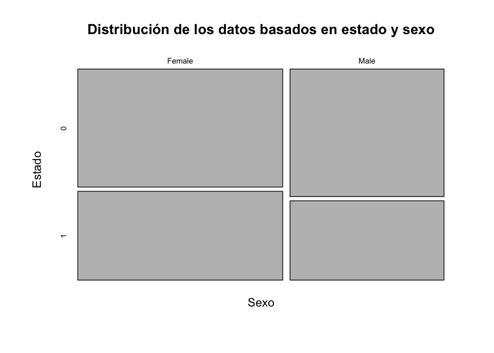

```r
mosaicplot(~Sexo+Estado, data=rh_data, main = "Distribución de los datos basados en estado y sexo", shade=F)
```

```r
chisq.test(rh_data$Sexo, rh_data$Estado)
```

```
##
##  Pearson's Chi-squared test with Yates' continuity correction
##
## data:  rh_data$Sexo and rh_data$Estado
## X-squared = 0.48585, df = 1, p-value = 0.4858
```

**Respuesta:**

```
No existe relación entre las variables, ya que se acepta la independencia entre ellas. Considerando un 95% de confianza. No se espera que sea una variable significativa.
```

#### Variable de interés Estado y Estado_Civil

```r
prop.table(table(rh_data$Estado, rh_data$Estado_Civil), 2)
```

```
##
##             1         2         3         4         5
##   0 0.4666667 0.5284553 0.6666667 0.6715328 0.5000000
##   1 0.5333333 0.4715447 0.3333333 0.3284672 0.5000000
```

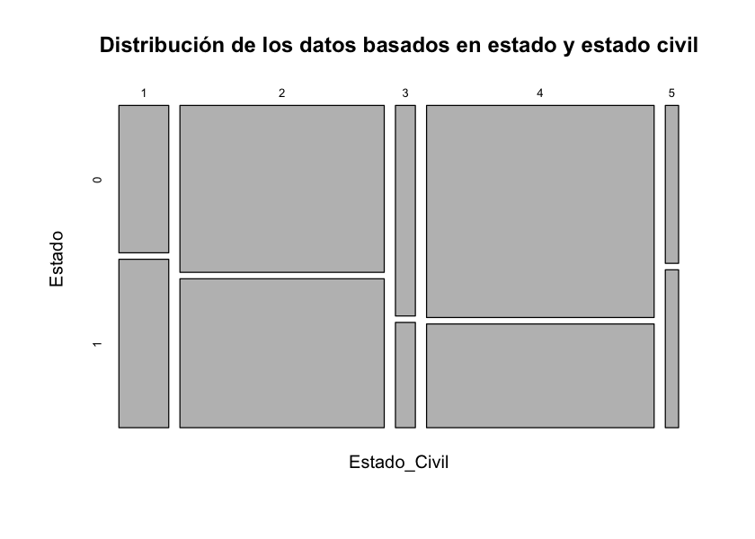

```r
mosaicplot(~Estado_Civil+Estado, data=rh_data, main = "Distribución de los datos basados en estado y estado civil", shade=F)
```

```r
chisq.test(rh_data$Estado_Civil, rh_data$Estado)
```

```
##
##  Pearson's Chi-squared test
##
## data:  rh_data$Estado_Civil and rh_data$Estado
## X-squared = 8.1386, df = 4, p-value = 0.08663
```

**Respuesta:**

```
No existe relación entre las variables, ya que se acepta la independencia entre ellas. considerando un 95% de confianza. No se espera que sea una variable significativa.
```

##### Variable de interés Estado y Departamento

```r
prop.table(table(rh_data$Estado, rh_data$Departamento), 2)
```

```
##
##     Admin Offices Executive Office     IT/IS Production     Sales
##   0     0.8000000        1.0000000 0.7000000  0.5096154 0.8387097
##   1     0.2000000        0.0000000 0.3000000  0.4903846 0.1612903
##
##     Software Engineering
##   0            0.7000000
##   1            0.3000000
```

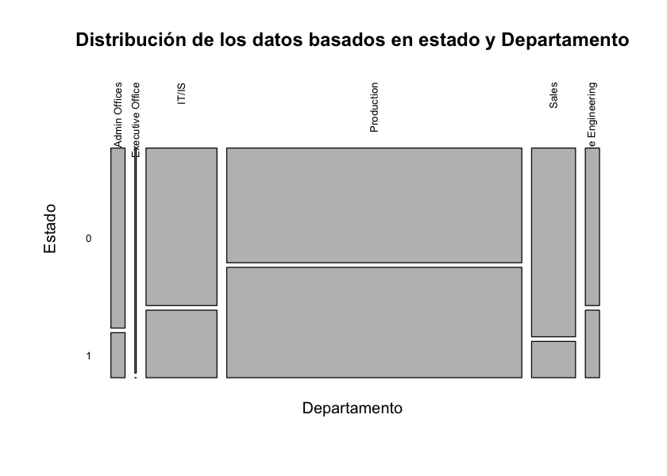

```r
mosaicplot(~Departamento+Estado, data=rh_data,  main = "Distribución de los datos basados en estado y Departamento", shade=F, las = 2)
```

```r
chisq.test(rh_data$Departamento, rh_data$Estado)
```

```
##
##  Pearson's Chi-squared test
##
## data:  rh_data$Departamento and rh_data$Estado
## X-squared = 19.007, df = 5, p-value = 0.001917
```

**Respuesta:**

```
Existe relación entre las variables,  que se rechaza la independencia entre ellas. considerando un 95% de confianza. Se espera que sea una variable significativa.
```

##### Variable de interés Estado y Posicion

```r
prop.table(table(rh_data$Estado,rh_data$Posicion), 2)
```

```
##
##     Accountant I Administrative Assistant Area Sales Manager BI Developer
##   0    1.0000000                0.6666667          0.8518519    1.0000000
##   1    0.0000000                0.3333333          0.1481481    0.0000000
##
##     BI Director       CIO Data Architect Database Administrator
##   0   1.0000000 1.0000000      1.0000000              0.5384615
##   1   0.0000000 0.0000000      0.0000000              0.4615385
##
##     Director of Operations Director of Sales IT Director IT Manager - DB
##   0              1.0000000         1.0000000   1.0000000       0.5000000
##   1              0.0000000         0.0000000   0.0000000       0.5000000
##
##     IT Manager - Infra IT Manager - Support IT Support Network Engineer
##   0          1.0000000            1.0000000  1.0000000        0.8888889
##   1          0.0000000            0.0000000  0.0000000        0.1111111
##
##     President & CEO Production Manager Production Technician I
##   0       1.0000000          0.6428571               0.5367647
##   1       0.0000000          0.3571429               0.4632353
##
##     Production Technician II Sales Manager Senior BI Developer
##   0                0.4035088     0.6666667           1.0000000
##   1                0.5964912     0.3333333           0.0000000
##
##     Shared Services Manager Software Engineer Software Engineering Manager
##   0               0.5000000         0.6666667                    1.0000000
##   1               0.5000000         0.3333333                    0.0000000
##
##     Sr. Accountant   Sr. DBA Sr. Network Engineer
##   0      1.0000000 0.0000000            0.4000000
##   1      0.0000000 1.0000000            0.6000000
```

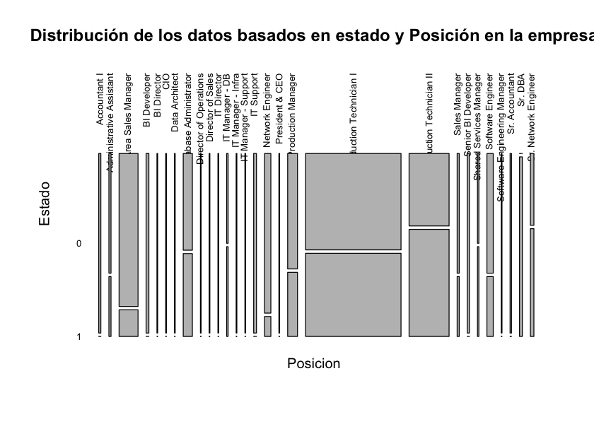

```r
mosaicplot(~Posicion+Estado, data=rh_data, main = "Distribución de los datos basados en estado y Posición en la empresa", shade=F, las = 2)
```

```r
chisq.test(rh_data$Posicion, rh_data$Estado)
```

```
##
##  Pearson's Chi-squared test
##
## data:  rh_data$Posicion and rh_data$Estado
## X-squared = 46.149, df = 27, p-value = 0.01226
```

**Respuesta:**

```
Existe relación entre las variables, ya que se rechaza la independencia entre ellas. considerando un 95% de confianza. Se espera que sea una variable significativa.
```

#### Variable de interés Estado y Desempeño

```r
prop.table(table(rh_data$Estado,rh_data$Desempenio), 2)
```

```
##
##     90-day meets   Exceeds Exceptional Fully Meets N/A- too early to review
##   0    0.5161290 0.6428571   1.0000000   0.6243094                0.4054054
##   1    0.4838710 0.3571429   0.0000000   0.3756906                0.5945946
##
##     Needs Improvement       PIP
##   0         0.4666667 0.5555556
##   1         0.5333333 0.4444444
```

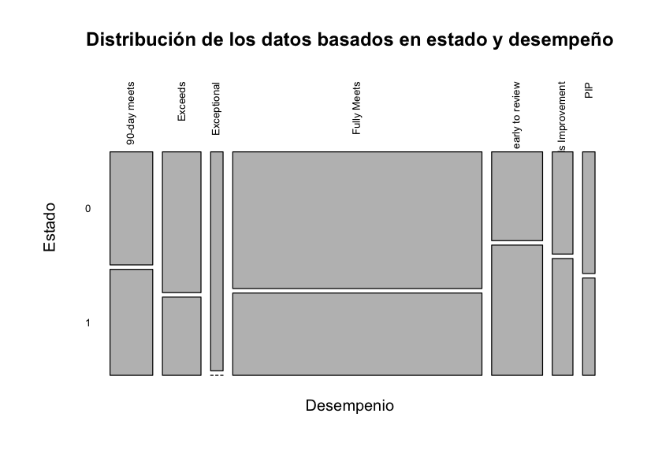

```r
mosaicplot(~Desempenio+Estado, data=rh_data, main = "Distribución de los datos basados en estado y desempeño", shade=F, las = 2)
```

```r
chisq.test(rh_data$Desempenio, rh_data$Estado)
```

```
##
##  Pearson's Chi-squared test
##
## data:  rh_data$Desempenio and rh_data$Estado
## X-squared = 14.36, df = 6, p-value = 0.02586
```

**Respuesta:**

```
Existe relación entre las variables, ya que se rechaza la independencia entre ellas considerando un 95% de confianza. Se espera que sea una variable significativa.
```

## E) Realice una separación de la base de datos en un set de entrenamiento y set de validación, utilice una proporción de 75:25 respectivamente. Para poder replicar sus resultados, fije una semilla antes de obtener los índices. Para ello, utilice la función set.seed(2021).

```r
set.seed(2021)
#listado de muestras a tomar
sampling <- sample(1:nrow(rh_data), size = 0.75*nrow(rh_data), replace = FALSE)
modelo_train <- rh_data %>% slice(sampling) #data de entrenamiento
modelo_test <- rh_data %>% slice(-sampling) #data de validación
```

## F) Con los datos de entrenamiento ajuste un modelo de regresión logística para estudiar la probabilidad de que el trabajador sea desvinculado de la empresa. Para ello, utilice las variables edad y desempeño.

```r
modelo_desvinculacion <- glm(Estado ~ Edad + Desempenio,
                             data = modelo_train,
                             family = binomial(link = "logit"))
summary(modelo_desvinculacion)
```

```
##
## Call:
## glm(formula = Estado ~ Edad + Desempenio, family = binomial(link = "logit"),
##     data = modelo_train)
##
## Deviance Residuals:
##     Min       1Q   Median       3Q      Max
## -1.6754  -0.9672  -0.7688   1.1903   1.8741
##
## Coefficients:
##                                      Estimate Std. Error z value Pr(>|z|)
## (Intercept)                          -1.73355    0.74664  -2.322  0.02024 *
## Edad                                  0.05007    0.01647   3.039  0.00237 **
## DesempenioExceeds                    -1.38505    0.68098  -2.034  0.04196 *
## DesempenioExceptional               -16.78511 1058.55891  -0.016  0.98735
## DesempenioFully Meets                -0.78597    0.45760  -1.718  0.08587 .
## DesempenioN/A- too early to review    0.40178    0.56572   0.710  0.47757
## DesempenioNeeds Improvement          -0.22693    0.74007  -0.307  0.75913
## DesempenioPIP                        -0.41360    0.88193  -0.469  0.63909
## ---
## Signif. codes:  0 '***' 0.001 '**' 0.01 '*' 0.05 '.' 0.1 ' ' 1
##
## (Dispersion parameter for binomial family taken to be 1)
##
##     Null deviance: 313.97  on 231  degrees of freedom
## Residual deviance: 290.26  on 224  degrees of freedom
## AIC: 306.26
##
## Number of Fisher Scoring iterations: 15
```

## G) Calcule e interprete los OR correspondientes al modelo,

## ¿son estos factores protectores o agravantes de la desvinculación del trabajador?

```r
broom::tidy(modelo_desvinculacion) %>% mutate(OR  = exp(estimate))
```

```
## # A tibble: 8 x 6
##   term                          estimate std.error statistic p.value          OR
##   <chr>                            <dbl>     <dbl>     <dbl>   <dbl>       <dbl>
## 1 (Intercept)                    -1.73      0.747    -2.32   0.0202      1.77e-1
## 2 Edad                            0.0501    0.0165    3.04   0.00237     1.05e+0
## 3 DesempenioExceeds              -1.39      0.681    -2.03   0.0420      2.50e-1
## 4 DesempenioExceptional         -16.8    1059.       -0.0159 0.987       5.13e-8
## 5 DesempenioFully Meets          -0.786     0.458    -1.72   0.0859      4.56e-1
## 6 DesempenioN/A- too early to …   0.402     0.566     0.710  0.478       1.49e+0
## 7 DesempenioNeeds Improvement    -0.227     0.740    -0.307  0.759       7.97e-1
## 8 DesempenioPIP                  -0.414     0.882    -0.469  0.639       6.61e-1
```

**Respuesta:**

```
Edad ~ A medida que aumenta la edad promedio del trabajador, mayor probabilidad de que este sea desvinculado. Esta variable es un factor con un OR > 1 por lo tanto definimos esta variable como un factor de riesgo

DesempenioExceeds ~ La probabilidad de desvinculación de un trabajador es menor si su desempeño es de tipo "DesempenioExceeds" respecto del desempeño de tipo "90-day meets". Esta variable es un factor con un OR < 1 por lo tanto definimos esta variable como un factor protector

DesempenioExceptional~ La probabilidad de desvinculación de un trabajador es menor si su desempeño es de tipo "DesempenioExceptional" respecto del desempeño de tipo "90-day meets". Esta variable es un factor con un OR < 1 por lo tanto definimos esta variable como un factor protector

DesempenioFully Meets~ La probabilidad de desvinculación de un trabajador es menor si su desempeño es de tipo "DesempenioFully Meets" respecto del desempeño de tipo "90-day meets". Esta variable es un factor con un OR < 1 por lo tanto definimos esta variable como un factor protector

DesempenioN/A- too early to review~ La probabilidad de desvinculación de un trabajador es mayor si su desempeño es de tipo "DesempenioN/A- too early to review" respecto del desempeño de tipo "90-day meets". Esta variable es un factor con un OR > 1 por lo tanto definimos esta variable como un factor de riesgo

DesempenioNeeds Improvement~ La probabilidad de desvinculación de un cliente es menor si su desempeño es de tipo "DesempenioNeeds Improvement". Esta variable es un factor con un OR < 1 por lo tanto definimos esta variable como un factor protector

DesempenioPIP ~ La probabilidad de desvinculación de un cliente es menor si su desempeño es de tipo "DesempenioPIP " respecto del desempeño de tipo "90-day meets". Esta variable es un factor con un OR < 1 por lo tanto definimos esta variable como un factor protector
```

# H) Utilizando un método automatizado, encuentre el modelo óptimo usando como criterio el criterio de información de Akaike (AIC). La función step() puede ser de utilidad.

```r
modelo_full <- glm(Estado ~ ., data = modelo_train, family = binomial(link = 'logit'))
modelo_nulo <- glm(Estado ~ 1, data = modelo_train, family = binomial(link = 'logit'))
modelo_backward <- step(modelo_full, birection = "backward")
```

```
## Start:  AIC=241.94
## Estado ~ Edad + Ratio_Pago + Salario + Dias_Trabajados + Ausencias +
##     Sexo + Estado_Civil + Departamento + Posicion + Desempenio
##
##
## Step:  AIC=241.94
## Estado ~ Edad + Ratio_Pago + Salario + Dias_Trabajados + Ausencias +
##     Sexo + Estado_Civil + Posicion + Desempenio
##
##                   Df Deviance    AIC
## - Estado_Civil     4   165.57 237.57
## - Ratio_Pago       1   162.11 240.11
## - Desempenio       6   172.20 240.20
## - Ausencias        1   162.49 240.49
## - Salario          1   162.86 240.86
## - Sexo             1   163.76 241.76
## - Posicion        23   207.93 241.93
## <none>                 161.94 241.94
## - Edad             1   168.42 246.42
## - Dias_Trabajados  1   233.63 311.63
##
## Step:  AIC=237.57
## Estado ~ Edad + Ratio_Pago + Salario + Dias_Trabajados + Ausencias +
##     Sexo + Posicion + Desempenio
##
##                   Df Deviance    AIC
## - Posicion        23   209.09 235.09
## - Desempenio       6   175.62 235.62
## - Ratio_Pago       1   165.68 235.68
## - Ausencias        1   165.96 235.96
## - Salario          1   166.60 236.60
## - Sexo             1   166.80 236.80
## <none>                 165.57 237.57
## - Edad             1   171.88 241.88
## - Dias_Trabajados  1   238.91 308.91
##
## Step:  AIC=235.09
## Estado ~ Edad + Ratio_Pago + Salario + Dias_Trabajados + Ausencias +
##     Sexo + Desempenio
##
```

[output cut: 37 more lines]

```
##                   Df Deviance    AIC
## - Salario          1   217.57 225.57
## <none>                 216.28 226.28
## - Edad             1   226.85 234.85
## - Ratio_Pago       1   232.00 240.00
## - Dias_Trabajados  1   298.07 306.07
##
## Step:  AIC=225.57
## Estado ~ Edad + Ratio_Pago + Dias_Trabajados
##
##                   Df Deviance    AIC
## <none>                 217.57 225.57
## - Edad             1   227.43 233.43
## - Ratio_Pago       1   233.69 239.69
## - Dias_Trabajados  1   298.20 304.20
```

```r
modelo_final <- modelo_backward

AIC(modelo_backward)
```

```
## [1] 225.57
```

```r
formula(modelo_backward)
```

```
## Estado ~ Edad + Ratio_Pago + Dias_Trabajados
```

**Respuesta:**

```
Al utilizar la función step, encontramos que utilizando la dirección "backward" encontramos el modelo que tiene el menor índice de AIC con un 225.57.
Este corresponde a la fórmula "Estado ~ Edad + Ratio_Pago + Dias_Trabajados"
```

# I) Si usted trabaja en la empresa ABAC, calcule su probabilidad de ser desvinculado.

# Suponga que sus características son:

- Edad: Edad del trabajador en años.
- Ratio.Pago: Medida de pago por hora (númerico)
- Salario: Salario mensual en dólares que tiene o tenía el trabajador
- Dias.trabajados: Días que lleva o llevaba trabajando en la empresa
- Ausencias: Días que ha faltado a trabajar
- Sexo: Sexo del trabajador (Female , Male)
- Estado.Civil: Estado civil del trabajador (1: divorciado, 2: casado,3: separado, 4: soltero, 5: viuda)
- Departamento: Lugar de trabajo en la empresa (Admin Offices,..)
- Posicion: Cargo del trabajador/empleado (Accountant I ,…. )
- Desempeño: Clasificación del desempeño del trabajador.

```r
new_data <- data.frame(
  Edad = 34,
  Ratio_Pago= 34.95,
  Salario = 3345.2,
  Dias_Trabajados = 3247,
  Ausencias = 16,
  Sexo = "Female",
  Estado_Civil = 2,
  Departamento= "Admin Offices",
  Posicion= "Sr. Accountant",
  Desempeño= "Fully Meets"
)

probabilidad <- predict.glm(modelo_final, newdata = new_data, type = "response")
probabilidad
```

```
##           1
## 0.004205649
```

**Respuesta:**

```
La probabilidad de ser desvinculado es muy cercana a 0 para el trabajador en cuestión
```

# Validación del modelo

## J) Utilizando la base de validación y el modelo obtenido en la pregunta anterior, calcule las probabilidades de que el trabajador sea desvinculado.

```r
probabilidad_desvinculacion <- predict.glm(modelo_final, newdata = modelo_test, type = "response")
probabilidad_desvinculacion
```

```
##           1           2           3           4           5           6
## 0.311183724 0.344374866 0.056991735 0.005622822 0.049217388 0.003791510
##           7           8           9          10          11          12
## 0.276190788 0.373068679 0.530985309 0.034125838 0.024973740 0.229047859
##          13          14          15          16          17          18
## 0.268279367 0.840569684 0.395926819 0.287512137 0.780257832 0.102327454
##          19          20          21          22          23          24
## 0.039211093 0.963229696 0.398129716 0.886217112 0.485510757 0.795694627
##          25          26          27          28          29          30
## 0.200202986 0.351648148 0.410927682 0.217745382 0.444849872 0.653905953
##          31          32          33          34          35          36
## 0.896586612 0.570384438 0.655033341 0.152954527 0.622481097 0.635506284
##          37          38          39          40          41          42
## 0.409567161 0.789505084 0.940155296 0.566914635 0.200647435 0.692116904
##          43          44          45          46          47          48
## 0.149552248 0.271085836 0.402702887 0.466708996 0.297118059 0.240951464
##          49          50          51          52          53          54
## 0.800732614 0.389344387 0.875918955 0.614015618 0.697573740 0.897146481
##          55          56          57          58          59          60
## 0.463021816 0.843037685 0.273086699 0.625982117 0.849879876 0.912530515
##          61          62          63          64          65          66
## 0.746801970 0.352868993 0.911518067 0.089881886 0.734803733 0.563378014
##          67          68          69          70          71          72
## 0.555744796 0.023051085 0.051837734 0.435556221 0.051020724 0.210574097
##          73          74          75          76          77          78
## 0.014836820 0.142197165 0.123331477 0.495479824 0.702428942 0.662384656
```

## K) Identifique el punto de corte que optimice la sensibilidad del modelo, pero que cometa como máximo una tasa de falsos positivos (1 - Especificidad) de a lo más un 25%. Use el argumento returnSensitivityMat = TRUE en la función plotROC(). Y obtenga las matrices de confusión y los indicadores de:

```r
# se oculta el comando dado que genera el gráfico que sube el peso al trabajo
# este se encuentra incluido como variable segun la siguiente fórmula.

# predictedscores <- predict.glm(modelo_final, modelo_test,type="response" )
# roc <- InformationValue::plotROC(actuals = modelo_test$Estado, predictedScores = predictedscores,           returnSensitivityMat = TRUE)

corte<-min(roc[roc$One_minus_specificity < 0.25, 'Threshold'])
corte
```

```
## [1] 0.5
```

**Respuesta:**

```
El punto de corte óptimo obtenido es de 0.5
```

### Matriz de confusión

```r
InformationValue::confusionMatrix(modelo_test$Estado,
                                  predictedscores,
                                  corte)
```

```
##    0  1
## 0 36 10
## 1 10 22
```

### Sensibilidad del modelo

```r
InformationValue::sensitivity(modelo_test$Estado,
                              predictedscores,
                              corte)
```

```
## [1] 0.6875
```

**Respuesta:**

```
Se presenta una sensibilidad de 0.6875
```

### Especificidad del modelo

```r
InformationValue::specificity(modelo_test$Estado,
                              predictedscores,
                              corte)
```

```
## [1] 0.7826087
```

**Respuesta:**

```
El modelo presenta una alta especificidad la cual tiene un valor de 0.7826087
```

### Precisión

```r
InformationValue::precision(modelo_test$Estado,
                            predictedscores,
                            corte)
```

```
## [1] 0.6875
```

**Respuesta:**

```
El modelo presenta una precisió de 0.6875
```

## L)Evalúe el modelo y concluya. Para ello, obtenga e interprete los siguientes estadísticos:

- Área bajo la curva ROC
- Test de Kolmogorov - Smirnov (Hint: utilice la función ks.test(x, y) ).
- Test de Hosmer - Lemeshow (Hint: utilice la función ResourceSelection::hoslem.test() ).

### Área bajo la curva ROC

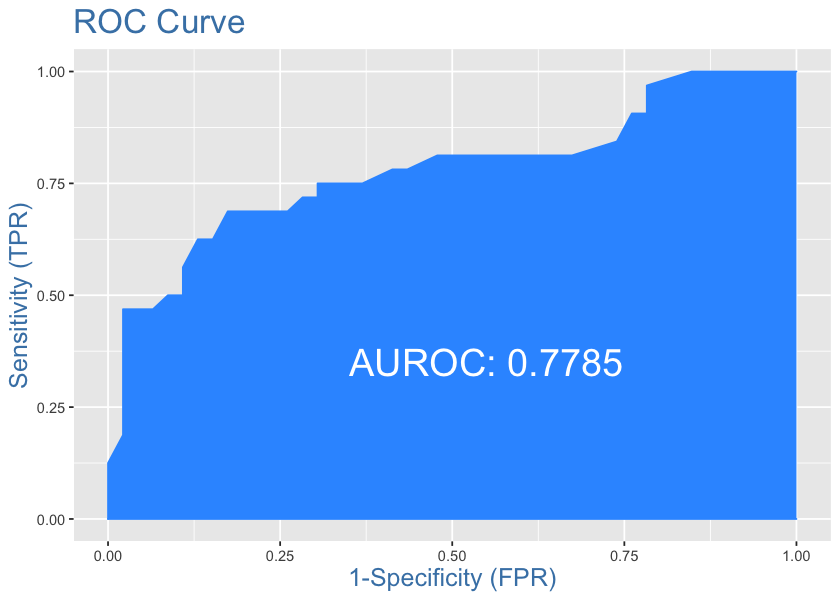

```
##    One_minus_specificity sensitivity Threshold
## 1             0.00000000     0.00000      1.00
## 2             0.00000000     0.00000      0.98
## 3             0.00000000     0.03125      0.96
## 4             0.00000000     0.06250      0.94
## 5             0.00000000     0.06250      0.92
## 6             0.00000000     0.12500      0.90
## 7             0.02173913     0.18750      0.88
## 8             0.02173913     0.21875      0.86
## 9             0.02173913     0.31250      0.84
## 10            0.02173913     0.31250      0.82
## 11            0.02173913     0.34375      0.80
## 12            0.02173913     0.43750      0.78
## 13            0.02173913     0.43750      0.76
## 14            0.02173913     0.46875      0.74
```

[output cut: 38 more lines]

```r
InformationValue::plotROC(actuals = modelo_test$Estado,
                          predictedScores = predictedscores,
                          returnSensitivityMat = TRUE)
```

**Respuesta:**

```
El valor del AUC es 0.7785, lo que corresponde a un buen ajuste
```

### Test de Kolmogorov - Smirnov (Hint: utilice la función ks.test(x, y) ).

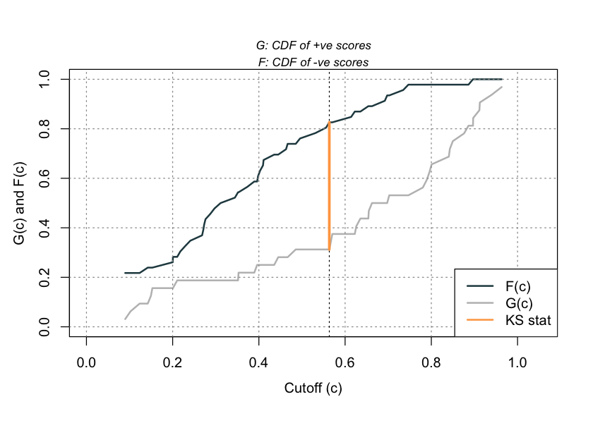

```r
ks <- ksplot(rocit(score = predictedscores, class = modelo_test$Estado))
```

```r
ks$`KS stat`
```

```
## [1] 0.513587
```

**Respuesta:**

```
El valor es 0.513587, siendo un buen poder predictivo para este modelo
```

### Test de Hosmer - Lemeshow

```r
DescTools::HosmerLemeshowTest(fit = probabilidad_desvinculacion , obs = modelo_test$Estado)
```

```
## $C
##
##  Hosmer-Lemeshow C statistic
##
## data:  probabilidad_desvinculacion and modelo_test$Estado
## X-squared = 36.911, df = 8, p-value = 1.195e-05
##
##
## $H
##
##  Hosmer-Lemeshow H statistic
##
## data:  probabilidad_desvinculacion and modelo_test$Estado
## X-squared = 23.868, df = 8, p-value = 0.002412
```

**Respuesta:**

```
Se rechaza la hipótesis nula dado que el valor valor p es < 5%, por ende existe diferencia entre los valores observados y pronosticados.
```